# Final_project_2

**DS 220: Project #2 23_24_PremierLeague Analysis**

**Data Analysis with Python Pandas - Hashem Badran**

**Professor Mathias Fonkam**

**Part 1: Introduction to the Dataset**

**In this Jupyter Notebook, I analyzed the Premier League dataset, which was obtained from a public data repository. The dataset includes detailed information about football matches in the English Premier League.**

**The purpose of this analysis is to explore various aspects of the data, such as team performances and match outcomes, to identify notable trends and insights. The dataset is comprehensive, covering several metrics that offer insights into the league's dynamics.**

**The objective of this project is to provide a clear analysis of the Premier League data. This involves not only presenting charts and graphs but also interpreting what the data suggests about the performance of different teams.**

**The analysis process involves several steps: loading the data, conducting an initial exploration to understand its contents, cleaning the data to prepare it for analysis, creating visualizations to illustrate the findings, and concluding with a summary of the insights.**

**For this project, I employed essential libraries like Pandas for data manipulation, Matplotlib for data visualization, Warnings, and Pyplot. Upon accessing the dataset, it was noted to contain 28 columns representing various statistics such as team names, games played, wins, losses, and goals, and etc, which provides a solid foundation for in-depth analysis.**

**Task 1: Importing the Libraries**

**In this section, I introduce and use important libraries to enhance the functionality of our notebook. I incorporateed the features of Matplotlib, which is crucial for creating visually appealing data visualizations. I also include code snippets to demonstrate their use. Additionally, the Pandas library is utilized, providing robust tools for effective data manipulation and detailed analysis within our notebook.**

```python
import pandas as pd
import numpy as np
from matplotlib import pyplot as plt
import seaborn as sns
import warnings
warnings.filterwarnings("ignore")
sns.set_style("darkgrid")
```

**Task 2: Loading the dataset**

```python
df = pd.read_csv('23_24_premier_league_0408_general.csv')
df
```

|  | league_position | squad | Home_MP | Home_W | Home_D | Home_L | Home_GF | Home_GA | Home_GD | Home_Pts | ... | Away_L | Away_GF | Away_GA | Away_GD | Away_Pts | Away_Pts/MP | Away_xG | Away_xGA | Away_xGD | Away_xGD/90 |
| --- | --- | --- | --- | --- | --- | --- | --- | --- | --- | --- | --- | --- | --- | --- | --- | --- | --- | --- | --- | --- | --- |
| 0 | 1 | Arsenal | 15 | 12 | 2 | 1 | 38 | 13 | 25 | 38 | ... | 3 | 37 | 11 | 26 | 33 | 2.06 | 28.9 | 11.5 | 17.5 | 1.09 |
| 1 | 2 | Liverpool | 16 | 13 | 3 | 0 | 43 | 14 | 29 | 42 | ... | 2 | 29 | 16 | 13 | 29 | 1.93 | 26.5 | 22.3 | 4.2 | 0.28 |
| 2 | 3 | Manchester City | 16 | 11 | 5 | 0 | 38 | 13 | 25 | 38 | ... | 3 | 33 | 18 | 15 | 32 | 2.13 | 32.0 | 17.3 | 14.7 | 0.98 |
| 3 | 4 | Tottenham | 16 | 12 | 0 | 4 | 34 | 21 | 13 | 36 | ... | 3 | 31 | 24 | 7 | 24 | 1.60 | 22.2 | 24.8 | -2.6 | -0.17 |
| 4 | 5 | Aston Villa | 16 | 11 | 2 | 3 | 40 | 22 | 18 | 35 | ... | 5 | 26 | 27 | -1 | 25 | 1.56 | 22.5 | 27.0 | -4.5 | -0.28 |
| 5 | 6 | Manchester Utd | 15 | 8 | 2 | 5 | 23 | 22 | 1 | 26 | ... | 7 | 22 | 24 | -2 | 23 | 1.44 | 21.2 | 32.3 | -11.1 | -0.69 |
| 6 | 7 | West Ham | 16 | 6 | 7 | 3 | 26 | 23 | 3 | 25 | ... | 7 | 26 | 33 | -7 | 23 | 1.44 | 23.6 | 33.0 | -9.4 | -0.59 |
| 7 | 8 | Newcastle Utd | 16 | 10 | 3 | 3 | 39 | 20 | 19 | 33 | ... | 9 | 26 | 32 | -6 | 14 | 0.93 | 20.3 | 31.8 | -11.6 | -0.77 |
| 8 | 9 | Chelsea | 15 | 7 | 4 | 4 | 29 | 25 | 4 | 25 | ... | 6 | 26 | 27 | -1 | 19 | 1.27 | 24.0 | 26.0 | -2.0 | -0.13 |
| 9 | 10 | Brighton | 15 | 7 | 6 | 2 | 28 | 19 | 9 | 27 | ... | 8 | 23 | 30 | -7 | 16 | 1.00 | 21.6 | 24.3 | -2.7 | -0.17 |
| 10 | 11 | Wolves | 15 | 7 | 3 | 5 | 23 | 23 | 0 | 24 | ... | 8 | 21 | 26 | -5 | 18 | 1.13 | 21.7 | 27.1 | -5.5 | -0.34 |
| 11 | 12 | Bournemouth | 16 | 6 | 5 | 5 | 21 | 24 | -3 | 23 | ... | 7 | 24 | 31 | -7 | 18 | 1.20 | 22.2 | 26.5 | -4.3 | -0.29 |
| 12 | 13 | Fulham | 16 | 9 | 1 | 6 | 29 | 16 | 13 | 28 | ... | 9 | 18 | 35 | -17 | 11 | 0.69 | 17.3 | 31.6 | -14.2 | -0.89 |
| 13 | 14 | Crystal Palace | 15 | 4 | 4 | 7 | 21 | 24 | -3 | 16 | ... | 8 | 15 | 30 | -15 | 14 | 0.88 | 15.7 | 25.8 | -10.1 | -0.63 |
| 14 | 15 | Brentford | 16 | 4 | 6 | 6 | 25 | 30 | -5 | 18 | ... | 11 | 20 | 28 | -8 | 11 | 0.69 | 22.3 | 24.2 | -1.8 | -0.11 |
| 15 | 16 | Everton | 15 | 4 | 4 | 7 | 16 | 18 | -2 | 16 | ... | 7 | 16 | 24 | -8 | 19 | 1.19 | 18.3 | 25.9 | -7.6 | -0.47 |
| 16 | 17 | Nott'ham Forest | 16 | 5 | 4 | 7 | 23 | 23 | 0 | 19 | ... | 10 | 17 | 33 | -16 | 10 | 0.63 | 20.9 | 27.7 | -6.8 | -0.43 |
| 17 | 18 | Luton Town | 16 | 4 | 3 | 9 | 24 | 27 | -3 | 15 | ... | 10 | 21 | 38 | -17 | 10 | 0.63 | 15.2 | 38.3 | -23.1 | -1.44 |
| 18 | 19 | Burnley | 16 | 2 | 3 | 11 | 16 | 36 | -20 | 9 | ... | 10 | 16 | 31 | -15 | 10 | 0.63 | 13.2 | 33.4 | -20.3 | -1.27 |
| 19 | 20 | Sheffield Utd | 16 | 2 | 4 | 10 | 17 | 47 | -30 | 10 | ... | 11 | 13 | 35 | -22 | 6 | 0.40 | 10.3 | 29.4 | -19.1 | -1.27 |

20 rows × 28 columns

**Part 2: Data Exploration**

**It's crucial to thoroughly explore the data before beginning any research. In this section, I aim to get a clearer view of the dataset. To achieve this, I display the first five rows and the last five rows of the data. Additionally, it's important to ascertain the structure of the dataset by checking the total number of rows and columns it contains, as well as understanding the data types and the non-null values across all columns.**

```python
#shows the top 5 rows of the data
df.head()
```

|  | league_position | squad | Home_MP | Home_W | Home_D | Home_L | Home_GF | Home_GA | Home_GD | Home_Pts | ... | Away_L | Away_GF | Away_GA | Away_GD | Away_Pts | Away_Pts/MP | Away_xG | Away_xGA | Away_xGD | Away_xGD/90 |
| --- | --- | --- | --- | --- | --- | --- | --- | --- | --- | --- | --- | --- | --- | --- | --- | --- | --- | --- | --- | --- | --- |
| 0 | 1 | Arsenal | 15 | 12 | 2 | 1 | 38 | 13 | 25 | 38 | ... | 3 | 37 | 11 | 26 | 33 | 2.06 | 28.9 | 11.5 | 17.5 | 1.09 |
| 1 | 2 | Liverpool | 16 | 13 | 3 | 0 | 43 | 14 | 29 | 42 | ... | 2 | 29 | 16 | 13 | 29 | 1.93 | 26.5 | 22.3 | 4.2 | 0.28 |
| 2 | 3 | Manchester City | 16 | 11 | 5 | 0 | 38 | 13 | 25 | 38 | ... | 3 | 33 | 18 | 15 | 32 | 2.13 | 32.0 | 17.3 | 14.7 | 0.98 |
| 3 | 4 | Tottenham | 16 | 12 | 0 | 4 | 34 | 21 | 13 | 36 | ... | 3 | 31 | 24 | 7 | 24 | 1.60 | 22.2 | 24.8 | -2.6 | -0.17 |
| 4 | 5 | Aston Villa | 16 | 11 | 2 | 3 | 40 | 22 | 18 | 35 | ... | 5 | 26 | 27 | -1 | 25 | 1.56 | 22.5 | 27.0 | -4.5 | -0.28 |

5 rows × 28 columns

```python
#shows the last 5 rows of the data
df.tail()
```

|  | league_position | squad | Home_MP | Home_W | Home_D | Home_L | Home_GF | Home_GA | Home_GD | Home_Pts | ... | Away_L | Away_GF | Away_GA | Away_GD | Away_Pts | Away_Pts/MP | Away_xG | Away_xGA | Away_xGD | Away_xGD/90 |
| --- | --- | --- | --- | --- | --- | --- | --- | --- | --- | --- | --- | --- | --- | --- | --- | --- | --- | --- | --- | --- | --- |
| 15 | 16 | Everton | 15 | 4 | 4 | 7 | 16 | 18 | -2 | 16 | ... | 7 | 16 | 24 | -8 | 19 | 1.19 | 18.3 | 25.9 | -7.6 | -0.47 |
| 16 | 17 | Nott'ham Forest | 16 | 5 | 4 | 7 | 23 | 23 | 0 | 19 | ... | 10 | 17 | 33 | -16 | 10 | 0.63 | 20.9 | 27.7 | -6.8 | -0.43 |
| 17 | 18 | Luton Town | 16 | 4 | 3 | 9 | 24 | 27 | -3 | 15 | ... | 10 | 21 | 38 | -17 | 10 | 0.63 | 15.2 | 38.3 | -23.1 | -1.44 |
| 18 | 19 | Burnley | 16 | 2 | 3 | 11 | 16 | 36 | -20 | 9 | ... | 10 | 16 | 31 | -15 | 10 | 0.63 | 13.2 | 33.4 | -20.3 | -1.27 |
| 19 | 20 | Sheffield Utd | 16 | 2 | 4 | 10 | 17 | 47 | -30 | 10 | ... | 11 | 13 | 35 | -22 | 6 | 0.40 | 10.3 | 29.4 | -19.1 | -1.27 |

5 rows × 28 columns

```python
#shows the shape of the data: (# of rows, # of columns)
df.shape
```

```
(20, 28)
```

```python
#shows the information of data types, non null values of all the columns in the dataset
df.info()
```

```
<class 'pandas.core.frame.DataFrame'>
RangeIndex: 20 entries, 0 to 19
Data columns (total 28 columns):
 #   Column           Non-Null Count  Dtype
---  ------           --------------  -----
 0   league_position  20 non-null     int64
 1   squad            20 non-null     object
 2   Home_MP          20 non-null     int64
 3   Home_W           20 non-null     int64
 4   Home_D           20 non-null     int64
 5   Home_L           20 non-null     int64
 6   Home_GF          20 non-null     int64
 7   Home_GA          20 non-null     int64
 8   Home_GD          20 non-null     int64
 9   Home_Pts         20 non-null     int64
```

[output cut: 20 more lines]

**Data Cleaning**

In this section, we will clean the data to ensure it is ready for subsequent analysis and visualization. This involves removing missing values and any irrelevant information to prepare a clean dataset.

```python
# shows the types of each column. We want everything to be a float/integer except the squad column
df.dtypes
```

```
league_position      int64
squad               object
Home_MP              int64
Home_W               int64
Home_D               int64
Home_L               int64
Home_GF              int64
Home_GA              int64
Home_GD              int64
Home_Pts             int64
Home_Pts/MP        float64
Home_xG            float64
Home_xGA           float64
Home_xGD           float64
Home_xGD/90        float64
Away_MP              int64
Away_W               int64
Away_D               int64
Away_L               int64
Away_GF              int64
Away_GA              int64
Away_GD              int64
Away_Pts             int64
Away_Pts/MP        float64
Away_xG            float64
Away_xGA           float64
Away_xGD           float64
Away_xGD/90        float64
dtype: object
```

```python
#checks if there is any missing values
df.isnull().sum()
```

```
league_position    0
squad              0
Home_MP            0
Home_W             0
Home_D             0
Home_L             0
Home_GF            0
Home_GA            0
Home_GD            0
Home_Pts           0
Home_Pts/MP        0
Home_xG            0
Home_xGA           0
Home_xGD           0
Home_xGD/90        0
Away_MP            0
Away_W             0
Away_D             0
Away_L             0
Away_GF            0
Away_GA            0
Away_GD            0
Away_Pts           0
Away_Pts/MP        0
Away_xG            0
Away_xGA           0
Away_xGD           0
Away_xGD/90        0
dtype: int64
```

**Since the dataset is in perfect condition with no missing values, I can proceed directly with the analysis. There is no need for data cleaning, allowing me to focus more on deriving insights and value from the data. This ensures that my analysis is both efficient and timely.**

**Data Analysis and Visualizations**

**In this section, I have created analyses and data visualizations based on the research questions and my insights into the dataset.**

**Research Question 1: Q1: How does the home win rate compare to the away win rate for each team?**

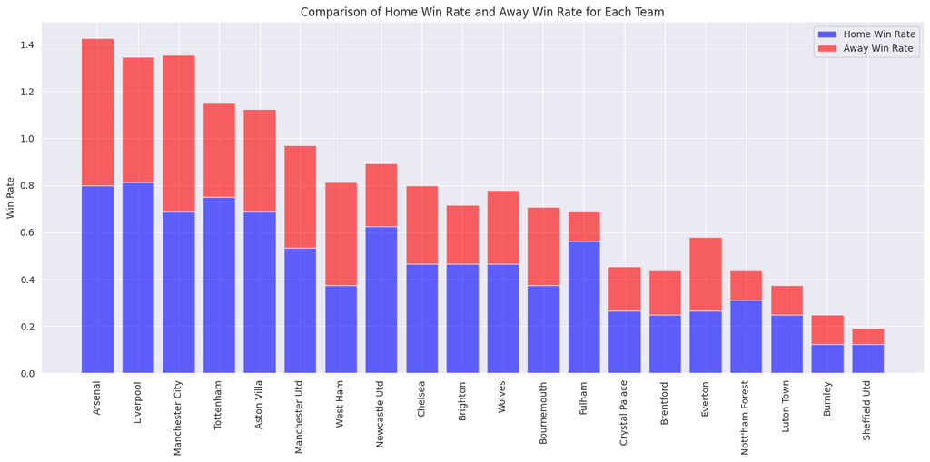

```python
question_plots = {}  # Create an empty dictionary to store plot figures.

home_win_rate = df['Home_W'] / df['Home_MP']  # Calculate the home win rate by dividing home wins by home matches played.
away_win_rate = df['Away_W'] / df['Away_MP']  # Calculate the away win rate by dividing away wins by away matches played.

question_plots['q1'] = plt.figure(figsize=(14, 7))  # Create a new figure for the plot and store it in the dictionary with key 'q1'.

plt.bar(df['squad'], home_win_rate, label='Home Win Rate', alpha=0.6, color='blue')  # Plot home win rates as blue bars.
plt.bar(df['squad'], away_win_rate, label='Away Win Rate', alpha=0.6, color='red', bottom=home_win_rate)  # Plot away win rates as red bars, stacked above the home win rates.

plt.xticks(rotation=90)  # Rotate the x-axis labels (team names) 90 degrees for better readability.
plt.ylabel('Win Rate')  # Set the y-axis label to 'Win Rate'.
plt.title('Comparison of Home Win Rate and Away Win Rate for Each Team')  # Set the title of the plot.
plt.legend()  # Add a legend to the plot to identify the blue and red bars.
plt.tight_layout()  # Automatically adjust subplot parameters to give specified padding and fit everything into the figure area.
plt.show()  # Display the plot.
```

Based on the graph provided, which compares the home win rate (blue) against the away win rate (red) for each team, here are three insights we can observe:

1. **Home Advantage Is Evident**: The blue bars, representing home win rates, are generally higher than the red bars for the away win rates for the majority of teams. This suggests a home advantage, where teams tend to win more frequently on their home ground than away.
2. **Variability in Away Performance**: Some teams have a significantly lower away win rate compared to their home win rate, indicating that these teams may struggle to replicate their home form when on the road. This could be due to various factors such as travel, lack of local support, or different pitch conditions.
3. **Consistent Teams**: A few teams show less discrepancy between their home and away win rates (Manchester City, West ham, Bournemouth), suggesting a level of consistency in their performance irrespective of the venue. These teams may have a more stable strategy or better adaptability to different playing conditions.

**Research Question 2: Is there a strong correlation between the number of goals scored at home (`Home_GF`) and the home points (`Home_Pts`)?**

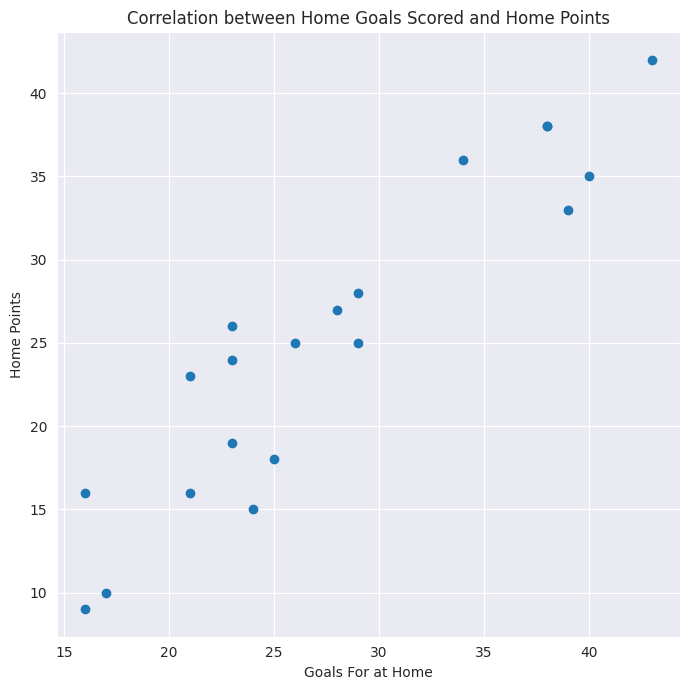

```python
question_plots['q2'] = plt.figure(figsize=(7, 7))  # Create a new figure for the plot and store it in the dictionary with key 'q2'.

plt.scatter(df['Home_GF'], df['Home_Pts'])  # Plot a scatter plot to show the relationship between goals scored at home and home points.

plt.xlabel('Goals For at Home')  # Set the x-axis label to 'Goals For at Home'.
plt.ylabel('Home Points')  # Set the y-axis label to 'Home Points'.
plt.title('Correlation between Home Goals Scored and Home Points')  # Set the title of the plot.

plt.grid(True)  # Enable the grid to improve readability and analysis of points distribution.
plt.tight_layout()  # Automatically adjust subplot parameters to give specified padding and fit everything into the figure area.
plt.show()  # Display the plot.
```

**Research Question 3: Does a higher xG differential (`Home_xGD/90` and `Away_xGD/90`) generally lead to a higher league position?**

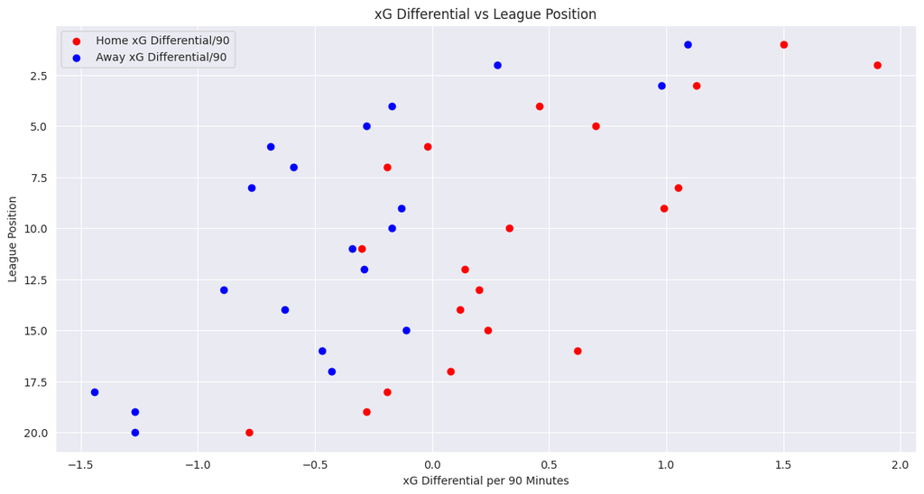

```python
question_plots['q3'] = plt.figure(figsize=(14, 7))  # Create a new figure for the plot and store it in the dictionary with key 'q3'.

plt.scatter(df['Home_xGD/90'], df['league_position'], label='Home xG Differential/90', color='red')  # Plot a scatter plot for home xG differential per 90 minutes against league position with red color.
plt.scatter(df['Away_xGD/90'], df['league_position'], label='Away xG Differential/90', color='blue')  # Plot a scatter plot for away xG differential per 90 minutes against league position with blue color.

plt.gca().invert_yaxis()  # Invert the y-axis to have higher positions at the top of the plot, which is typical for league standings.

plt.xlabel('xG Differential per 90 Minutes')  # Set the x-axis label to 'xG Differential per 90 Minutes'.
plt.ylabel('League Position')  # Set the y-axis label to 'League Position'.
plt.title('xG Differential vs League Position')  # Set the title of the plot.

plt.legend()  # Add a legend to identify red and blue points as home and away differentials.
plt.grid(True)  # Enable the grid to improve readability and analysis of points distribution.
plt.show()  # Display the plot.
```

The scatter plot provided displays the relationship between a team's expected goals (xG) differential per 90 minutes for both home (red) and away (blue) games and their league positions. Here are three insights we can derive from the plot:

1. **Higher xG Differential Correlates with Better League Position**: Teams with higher xG differentials, both at home and away, tend to be positioned higher in the league standings. This is evidenced by the concentration of red and blue dots further to the right corresponding to lower (better) league positions.
2. **Home Ground Advantage**: It seems that for many teams, the home xG differential (red dots) is higher than the away xG differential (blue dots), which is consistent with the common understanding of home advantage. Teams are likely creating more and conceding fewer quality chances at home.
3. **Consistency Across Venues**: Some teams have similar xG differentials for both home and away games, as indicated by red and blue dots being close horizontally. These teams appear to maintain a consistent level of performance regardless of the venue.

The position on the y-axis represents the league position, with the lower (top of the chart) being better. The position on the x-axis represents the xG differential, with further to the right being a higher differential. The pattern observed suggests that having a positive xG differential is a strong indicator of a team's success in the league.

**Research Question 4: How does the expected goals difference (`Home_xGD` and `Away_xGD`) compare to the actual goal difference (`Home_GD` and `Away_GD`) for the top 5 teams?**

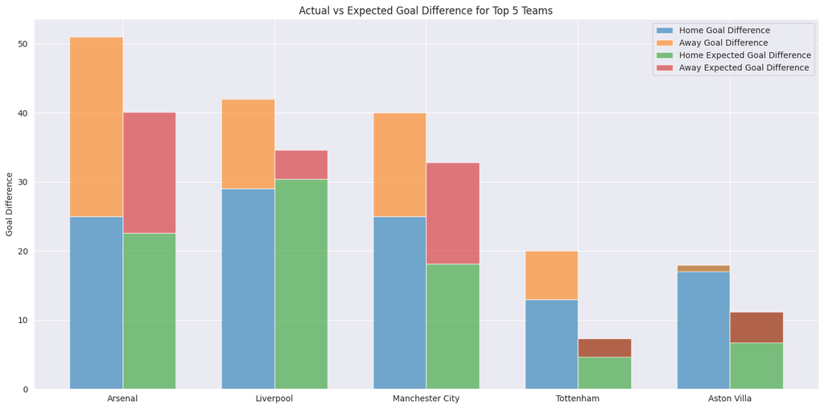

```python
# Select the top 5 teams based on ascending league positions
top_5 = df.nsmallest(5, 'league_position')  # Retrieve the top 5 rows with the smallest values in the 'league_position' column.

# Plotting the data
question_plots['q4'] = plt.figure(figsize=(14, 7))  # Create a new figure for the plot and store it in the dictionary with key 'q4'.

bar_width = 0.35  # Set the width of the bars for the bar chart.
index = range(len(top_5))  # Create a range object to serve as the positions for the bar groups.

# Plot actual home and away goal differences as stacked bars
plt.bar(index, top_5['Home_GD'], bar_width, label='Home Goal Difference', alpha=0.6)  # Plot home goal difference as bars.
plt.bar(index, top_5['Away_GD'], bar_width, label='Away Goal Difference', alpha=0.6, bottom=top_5['Home_GD'])  # Stack away goal difference on top of home goal difference.

# Plot expected home and away goal differences as stacked bars next to the actual differences
plt.bar([i + bar_width for i in index], top_5['Home_xGD'], bar_width, label='Home Expected Goal Difference', alpha=0.6)  # Plot home expected goal difference as bars, offset by bar_width.
plt.bar([i + bar_width for i in index], top_5['Away_xGD'], bar_width, label='Away Expected Goal Difference', alpha=0.6, bottom=top_5['Home_xGD'])  # Stack away expected goal difference on top of home expected goal difference.

plt.xticks([i + bar_width / 2 for i in index], top_5['squad'])  # Set x-tick positions to the middle of the grouped bars and label them with team names.
plt.ylabel('Goal Difference')  # Set the y-axis label to 'Goal Difference'.
plt.title('Actual vs Expected Goal Difference for Top 5 Teams')  # Set the title of the plot.

plt.legend()  # Add a legend to identify the different bars.
plt.tight_layout()  # Automatically adjust subplot parameters to give specified padding and fit everything into the figure area.
plt.show()  # Display the plot.
```

Based on the graph provided:

1. **Comparison of Actual vs Expected Goal Difference**: The graph illustrates a comparison between actual and expected goal differences for both home and away games for the top 5 teams. We can see that for some teams, the actual goal difference is higher than the expected goal difference, which could indicate that these teams are performing better than statistical models would predict.
2. **Home Advantage**: It appears that for most teams shown, the home goal difference (both actual and expected) is greater than the away goal difference. This suggests a home advantage, where teams tend to perform better when playing on their home turf.
3. **Performance Variance**: There's a noticeable variance in performance among the top 5 teams. Some teams have a significant disparity between their home and away performances (actual and expected), while others have more balanced results. For instance, the team represented by the leftmost set of bars (Arsenal) seems to have a relatively balanced home and away actual goal difference, whereas the second team from the right (Tottenham) shows a more pronounced difference between home and away performance. This could imply strategic differences, the impact of travel on the team, or other external factors affecting away games more significantly.

**Research Question 5: Which team overperforms on the road compared to their home games, based on points per match (`Home_Pts/MP` vs `Away_Pts/MP`)?**

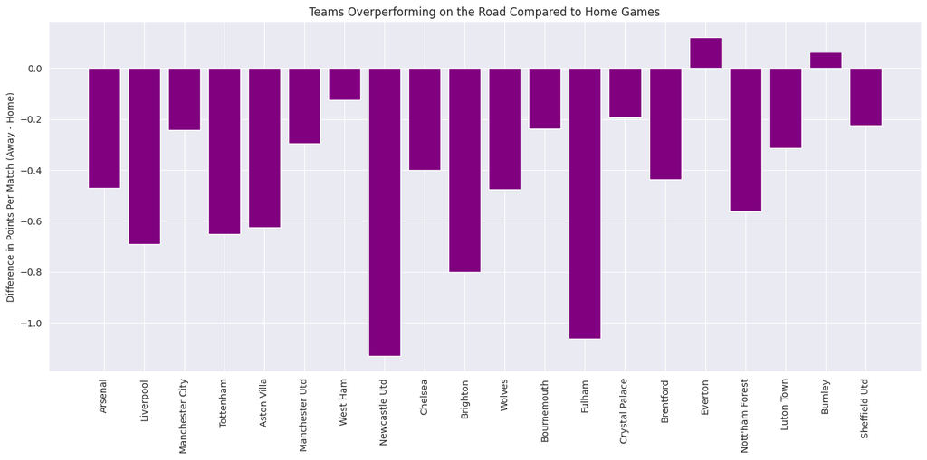

```python
# Calculate points per match for home and away games
df['Home_Pts/MP'] = df['Home_Pts'] / df['Home_MP']  # Compute the average home points per match by dividing total home points by home matches played.
df['Away_Pts/MP'] = df['Away_Pts'] / df['Away_MP']  # Compute the average away points per match by dividing total away points by away matches played.

# Calculate the difference in points per match between away and home performances
overperformance = df['Away_Pts/MP'] - df['Home_Pts/MP']  # Calculate the difference in points per match for away games versus home games.

# Plotting the data
question_plots['q5'] = plt.figure(figsize=(14, 7))  # Create a new figure for the plot and store it in the dictionary with key 'q5'.

plt.bar(df['squad'], overperformance, color='purple')  # Plot a bar chart showing the difference in points per match (away minus home) for each squad in purple.

plt.xticks(rotation=90)  # Rotate the x-axis labels (team names) 90 degrees for better readability.
plt.ylabel('Difference in Points Per Match (Away - Home)')  # Set the y-axis label to show what the bar heights represent.
plt.title('Teams Overperforming on the Road Compared to Home Games')  # Set the title of the plot to describe the chart's focus.

plt.tight_layout()  # Automatically adjust subplot parameters to give specified padding and fit everything into the figure area.
plt.show()  # Display the plot.
```

**Research Question 6: Are teams more likely to draw away games than at home (`Home_D` vs `Away_D`)?**

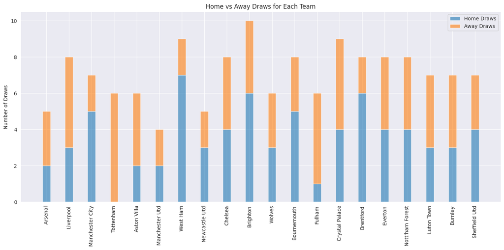

```python
bar_width = 0.35  # Set the width of the bars for the bar chart.

question_plots['q6'] = plt.figure(figsize=(14, 7))  # Create a new figure for the plot and store it in the dictionary with key 'q6'.

plt.bar(df['squad'], df['Home_D'], bar_width, label='Home Draws', alpha=0.6)  # Plot the number of home draws as bars with 60% opacity.
plt.bar(df['squad'], df['Away_D'], bar_width, label='Away Draws', alpha=0.6, bottom=df['Home_D'])  # Stack the number of away draws on top of home draws for each team.

plt.xticks(rotation=90)  # Rotate the x-axis labels (team names) 90 degrees to ensure they are legible.
plt.ylabel('Number of Draws')  # Set the y-axis label to 'Number of Draws'.
plt.title('Home vs Away Draws for Each Team')  # Set the title of the plot to indicate what is being compared.

plt.legend()  # Add a legend to help identify the bars corresponding to home and away draws.
plt.tight_layout()  # Automatically adjust subplot parameters to give specified padding and fit everything into the figure area.
plt.show()  # Display the plot.
```

The bar graph illustrates the number of draws each team has had at home (in blue) versus away (in orange). Here are three insights that can be gleaned from the graph:

1. **Draw Tendency**: Some teams tend to draw more games away from home, as indicated by the orange bars being taller than the blue bars. This might suggest a more cautious approach or conservative strategy when playing away.
2. **Balanced Outcomes**: For teams with similar heights of blue and orange bars, this indicates a balance in draw outcomes regardless of playing at home or away. These teams may play with a consistent style that leads to draws across different venues.
3. **Home Caution**: A few teams have a higher number of draws at home than away, shown by taller blue bars. This could be indicative of playing with more restraint in front of home fans or could reflect the competitive nature of the league where no team can be underestimated.

**Conclusion:**

**Based on the visualizations provided, it is evident that team performance in the Premier League varies considerably when comparing home and away matches. The data suggests a prevailing home-field advantage, with many teams securing a higher rate of wins in their own stadiums. This advantage is likely influenced by familiar playing conditions, the support of local fans, and the absence of travel fatigue. However, it's noteworthy that some teams exhibit a strong performance during away matches, defying conventional expectations and demonstrating a high level of adaptability and resilience in unfamiliar environments.**

**The analysis also indicates a positive correlation between goals scored at home and points accumulated, reinforcing the importance of a strong offensive strategy in securing a favorable league position. Additionally, the examination of expected goals (xG) differentials points to the potential overperformance or underperformance of teams compared to statistical expectations. Some teams' actual performance exceeds their predicted metrics, which might reflect effective tactics or, conversely, highlight areas for improvement. Ultimately, this exploration of the Premier League data through various graphical representations provides valuable insights into the complex dynamics of football performance and underscores the multifaceted nature of success in the sport.**